# autocorrelation

Lukáš ‘hejtmy’ Hejtmánek

06/10/2020

## Checking component correlation between participants

The goal of this sanity check is to observe if the component and modeled HRFs do not strongly correlate between subjects.

### Single compoment visualisation

This is to simply visualise how a single component correlates between individual subjects. The correlations are made ABSOLUTE to better visualize any form of dependence.

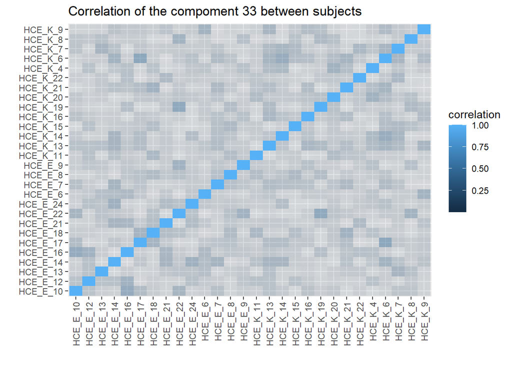

The average absolute correlation of the component 33 between subjects was 0.1021986.

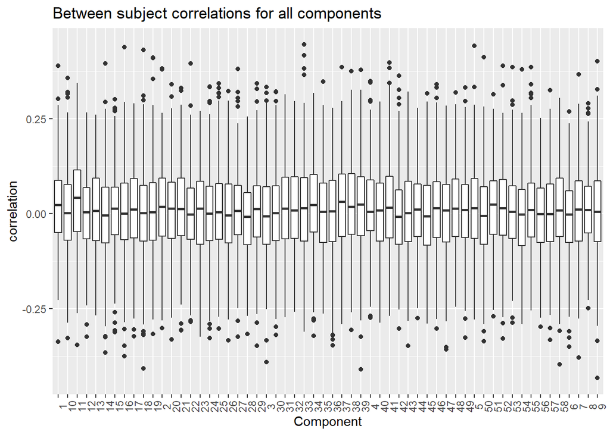

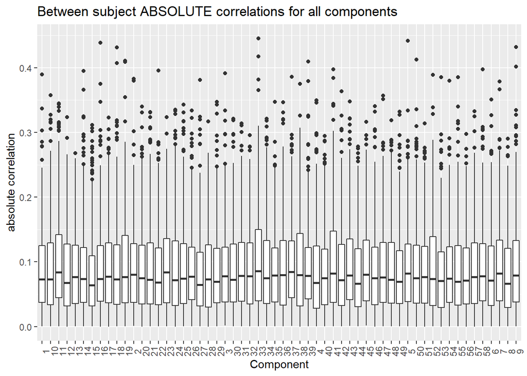

## Correlation between the HRFs

Similar method can be used to track the HRF correlation between movement and pointing. The events ARE to certain extent to be expected ti correlated. This is due to the fact that the trials start forcefully after 60s, meaning that some subjects, who rarely finish the task earlier and thus always start a new at 60s mark, can always be pointing at the same times (60,120,180 etc.). Similarly movement is quite pronounced, as participants need to be constantly moving to finish the task on time, so some intercorelation is to be expected.

I am analysing solely movement HRF, as that should be fairly independent between subjects, as they are free to stop and start whenever they wish.

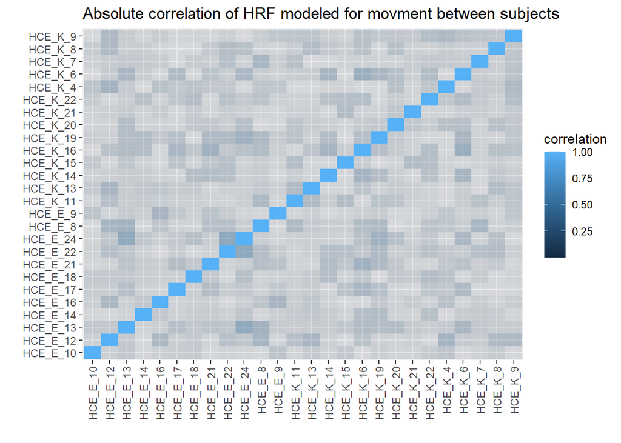

The average correlation of the movement between subjects was 0.093958.

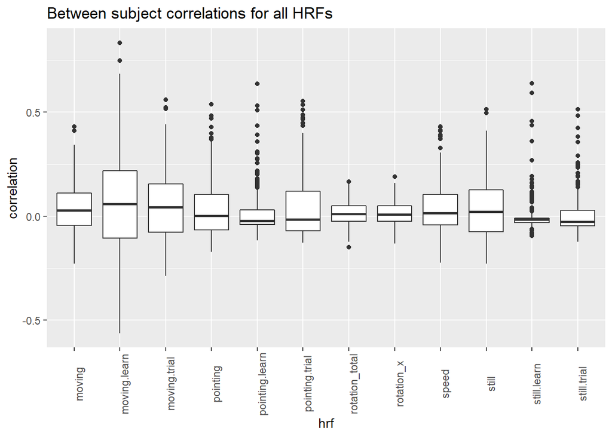

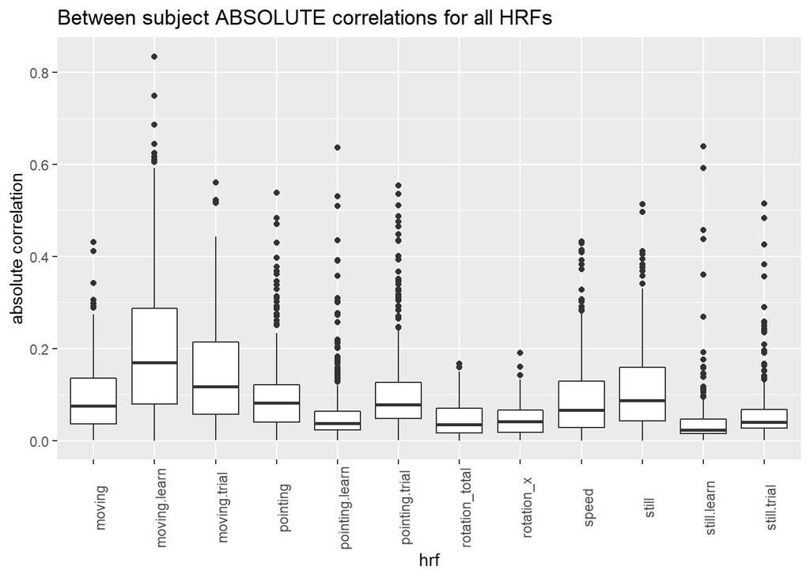